# Case Study 1

Yujia Jin

2022/4/9

#### Describe the dataset and any issues with it.

This dataset shows 10,000 observations of loans made through the lending Club platform. There are 55 variables within the dataset, which contain the information of each client and the loan. All these variables could possibly affects the label interest rate for each observation. One of the main issues of this dataset is that the value “NA” could be misleading. We are not sure is that means “Not Applicable” or missing value. We should decide the meaning by ourselves.

#### Generate a minimum of 5 unique visualizations using the data and write a brief description of your observations. Additionally, all attempts should be made to make the visualizations visually appealing

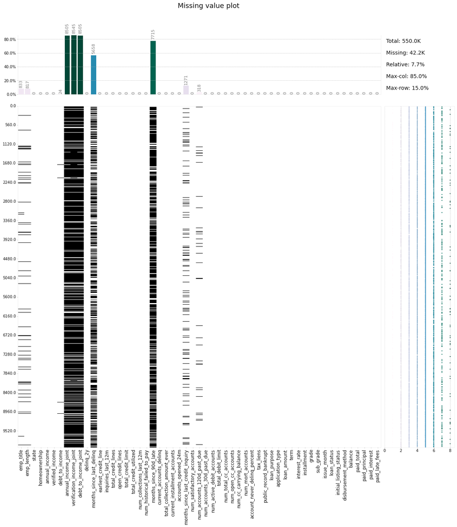

This plot above has shown the general missing values of the whole dataset. Remove the columns with large proportion of missing values to faciliate later analysis.

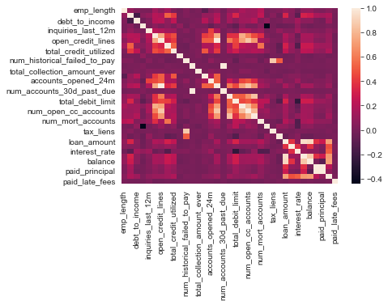

This plot shows the correlation heatmap of significant numerical variables of the dataframe. According to this visualization, it can see that the interested attribute “interest_rate” does not show any strong relationship to any other attributes. Only few attributes shows strong correlation to each others.

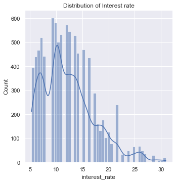

This histogram shows the distribution of interest rate of loans made through the Lending Club platform. From this visualization, it shows that most common interest rate are at around 10, and 10-15 is a common range. Generally, it is more common to see the relatively lower interest rate than high interest rate.

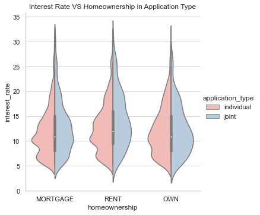

This violin plot shows the relationship between different home-ownership in different application type and interest rate. This visualization tries to explore how home-ownership and application type of applicants related to the interest rate. According to this plot, it can see that the distribution of interest rate do not show that much difference. The home-ownership of rent has slightly higher interest rate than other status.

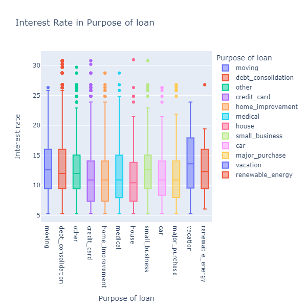

This boxplot presents the distribution of interest rates in different purpose of loan. According to this plot, it shows that purpose of loan used as vacation has relatively higher median interest rate than others, small business ranks the second and moving ranks the third. On the other hand, the purpose of loan on house and credit card has lowest median interest rate.

#### Create a feature set and create a model which predicts interest_rate using at least 2 algorithms. Describe any data cleansing that must be performed and analysis when examining the data.

The important data cleansing must performed here is drop the rows and columns with lots of missing values.

```r
# drop some columns
df = read.csv("case_study1_df.csv")
head(df) %>%
  kbl() %>%
  kable_styling(bootstrap_options = "striped",full_width = F,
                position = "center")
```

| emp_length | state | homeownership | annual_income | verified_income | debt_to_income | delinq_2y | earliest_credit_line | inquiries_last_12m | total_credit_lines | open_credit_lines | total_credit_limit | total_credit_utilized | num_collections_last_12m | num_historical_failed_to_pay | current_accounts_delinq | total_collection_amount_ever | current_installment_accounts | accounts_opened_24m | num_satisfactory_accounts | num_accounts_30d_past_due | num_active_debit_accounts | total_debit_limit | num_total_cc_accounts | num_open_cc_accounts | num_cc_carrying_balance | num_mort_accounts | account_never_delinq_percent | tax_liens | public_record_bankrupt | … |
| --- | --- | --- | --- | --- | --- | --- | --- | --- | --- | --- | --- | --- | --- | --- | --- | --- | --- | --- | --- | --- | --- | --- | --- | --- | --- | --- | --- | --- | --- | --- |
| 3 | NJ | MORTGAGE | 90000 | Verified | 18.01 | 0 | 2001 | 6 | 28 | 10 | 70795 | 38767 | 0 | 0 | 0 | 1250 | 2 | 5 | 10 | 0 | 2 | 11100 | 14 | 8 | 6 | 1 | 92.9 | 0 | 0 | … |
| 10 | HI | RENT | 40000 | Not Verified | 5.04 | 0 | 1996 | 1 | 30 | 14 | 28800 | 4321 | 0 | 1 | 0 | 0 | 0 | 11 | 14 | 0 | 3 | 16500 | 24 | 14 | 4 | 0 | 100.0 | 0 | 1 | … |
| 3 | WI | RENT | 40000 | Source Verified | 21.15 | 0 | 2006 | 4 | 31 | 10 | 24193 | 16000 | 0 | 0 | 0 | 432 | 1 | 13 | 10 | 0 | 3 | 4300 | 14 | 8 | 6 | 0 | 93.5 | 0 | 0 | … |
| 1 | PA | RENT | 30000 | Not Verified | 10.16 | 0 | 2007 | 0 | 4 | 4 | 25400 | 4997 | 0 | 1 | 0 | 0 | 1 | 1 | 4 | 0 | 2 | 19400 | 3 | 3 | 2 | 0 | 100.0 | 1 | 0 | … |
| 10 | CA | RENT | 35000 | Verified | 57.96 | 0 | 2008 | 7 | 22 | 16 | 69839 | 52722 | 0 | 0 | 0 | 0 | 1 | 6 | 16 | 0 | 10 | 32700 | 20 | 15 | 13 | 0 | 100.0 | 0 | 0 | … |
| 10 | MI | MORTGAGE | 35000 | Source Verified | 23.66 | 0 | 2004 | 1 | 12 | 10 | 291852 | 18916 | 0 | 0 | 0 | 0 | 2 | 1 | 10 | 0 | 3 | 9100 | 8 | 7 | 6 | 2 | 100.0 | 0 | 0 | … |

```r
df <- select(df,-c("state"))
```

```r
set.seed(205)

split <- sample(c(rep(0,0.8*nrow(df)),rep(1,0.2*nrow(df))))

train.data <- df[split ==0,]
test.data <- df[split ==1,]

mod1 <- lm(interest_rate ~., data = train.data)
```

```r
library(tidyverse)
library(caret)
pred = mod1 %>% predict(test.data)
rmse1 <- RMSE(pred,test.data$interest_rate);
r21 <- R2(pred,test.data$interest_rate)
print(rmse1)
```

```
## [1] 0.07631084
```

```r
print(r21)
```

```
## [1] 0.9997822
```

Second model with filtered attributes

```r
mod2 <- lm(interest_rate ~ total_credit_lines + term +
             installment + grade + sub_grade + issue_month +
           initial_listing_status , data = train.data)
#summary(mod1)
```

```r
pred2 = mod2 %>% predict(test.data)
rmse2 <- RMSE(pred,test.data$interest_rate);
r22 <- R2(pred2,test.data$interest_rate)
print(rmse2)
```

```
## [1] 0.07631084
```

```r
print(r22)
```

```
## [1] 0.9997926
```